# Rainfall-Prediction-ML-NN

> In order to build our forecasting model, we will have to opt for using CRISP-DM methodology.

**1. Business understanding**

This first step is essentially about understanding the business, the need for the specific project and the resources that we have.

1.1 **Gather background information**

*Compiling the business background*

this project is about historical weather around Szeged, Hungary , from 2006 to 2016

**Defining business objectives**

Make data more accessible and understandable for everyone.

Provide fast analytics for the different Factors Affecting Weather .

use different prediction and classification algorithms

calculating and comparing evaluation measures

**1.2 Assessing the situation**

**Resource Inventory**

Data : dataset contains in a practical format 10 years (2006-2016) of hourly data in just a single file.

Computing resources : hp , i3 processor, 4 GB RAM

Programming languages and libraries : python ( Numpy, pandas, matplotlib, seaborn, tensorflow, scikitlearn)

**1.3 Objective of the project**

the objective of this project is to analyze the weather data and extract the hypotheses to arrive at a prediction

**2.Collect initial data**

Dataset from Kaggle : https://www.kaggle.com/budincsevity/szeged-weather

**2.1 Data Exploration**

Exploration is to understand how all these columns are related and the value structures so the correlation between these data

**importing libraries**

```python
#Data manipulation libraries :
import numpy as np  #numpy
import pandas as pd  #pandas
import tensorflow as tf
#System libraries
import glob #The glob module finds all the pathnames matching a specified pattern according to the rules used by the Unix shell

#Map plotting
import folium #Interactive Maps viz



#Plotting
import seaborn as sns
import matplotlib.pyplot as plt
import matplotlib.dates as mdates

#math operations lib
import math
from math import pi

#date manipulation
import datetime as dt

#Missing data detector lib
import missingno as mn

#Impute missing data
from sklearn.impute  import SimpleImputer as Imputer

#Deep learning with keras
from keras import backend as K
import keras
from keras.models import Sequential
from keras.layers import Dense, Dropout

#Splitting data to test and train
from sklearn.model_selection import train_test_split

import datetime
from sklearn.model_selection import train_test_split
from sklearn.metrics import accuracy_score
from sklearn.tree import DecisionTreeClassifier
from sklearn.linear_model import LogisticRegression
from tensorflow import keras
%matplotlib inline
plt.style.use('seaborn-whitegrid')

from mpl_toolkits.mplot3d import Axes3D
from sklearn.preprocessing import StandardScaler
from collections import Counter
import time
import datetime as dt
from datetime import datetime
import collections
import os # accessing directory structure
import pandas as pd # data processing, CSV file I/O (e.g. pd.read_csv)
import seaborn as sns
from matplotlib.pyplot import rcParams

from sklearn import linear_model
```

```python
from datetime import datetime
```

```python
data = pd.read_csv('weatherHistory.csv', nrows=1464, parse_dates=[0])
data.head()
```

|  | Formatted Date | Summary | Precip Type | Temperature (C) | Apparent Temperature (C) | Humidity | Wind Speed (km/h) | Wind Bearing (degrees) | Visibility (km) | Loud Cover | Pressure (millibars) | Daily Summary |
| --- | --- | --- | --- | --- | --- | --- | --- | --- | --- | --- | --- | --- |
| 0 | 2006-04-01 00:00:00+02:00 | Partly Cloudy | rain | 9.472222 | 7.388889 | 0.89 | 14.1197 | 251.0 | 15.8263 | 0.0 | 1015.13 | Partly cloudy throughout the day. |
| 1 | 2006-04-01 01:00:00+02:00 | Partly Cloudy | rain | 9.355556 | 7.227778 | 0.86 | 14.2646 | 259.0 | 15.8263 | 0.0 | 1015.63 | Partly cloudy throughout the day. |
| 2 | 2006-04-01 02:00:00+02:00 | Mostly Cloudy | rain | 9.377778 | 9.377778 | 0.89 | 3.9284 | 204.0 | 14.9569 | 0.0 | 1015.94 | Partly cloudy throughout the day. |
| 3 | 2006-04-01 03:00:00+02:00 | Partly Cloudy | rain | 8.288889 | 5.944444 | 0.83 | 14.1036 | 269.0 | 15.8263 | 0.0 | 1016.41 | Partly cloudy throughout the day. |
| 4 | 2006-04-01 04:00:00+02:00 | Mostly Cloudy | rain | 8.755556 | 6.977778 | 0.83 | 11.0446 | 259.0 | 15.8263 | 0.0 | 1016.51 | Partly cloudy throughout the day. |

```python
len(data)
```

```
1464
```

```python
data.tail(100)
```

|  | Formatted Date | Summary | Precip Type | Temperature (C) | Apparent Temperature (C) | Humidity | Wind Speed (km/h) | Wind Bearing (degrees) | Visibility (km) | Loud Cover | Pressure (millibars) | Daily Summary |
| --- | --- | --- | --- | --- | --- | --- | --- | --- | --- | --- | --- | --- |
| 1364 | 2006-08-05 20:00:00+02:00 | Partly Cloudy | rain | 19.055556 | 19.055556 | 0.73 | 6.9069 | 288.0 | 11.0285 | 0.0 | 1010.35 | Partly cloudy until evening. |
| 1365 | 2006-08-05 21:00:00+02:00 | Partly Cloudy | rain | 17.250000 | 17.250000 | 0.81 | 4.8783 | 261.0 | 11.2056 | 0.0 | 0.00 | Partly cloudy until evening. |
| 1366 | 2006-08-05 22:00:00+02:00 | Clear | rain | 16.161111 | 16.161111 | 0.86 | 8.3398 | 270.0 | 9.9820 | 0.0 | 0.00 | Partly cloudy until evening. |
| 1367 | 2006-08-05 23:00:00+02:00 | Clear | rain | 15.327778 | 15.327778 | 0.89 | 6.3756 | 255.0 | 14.9569 | 0.0 | 1011.69 | Partly cloudy until evening. |
| 1368 | 2006-08-06 00:00:00+02:00 | Clear | rain | 13.988889 | 13.988889 | 0.92 | 9.7405 | 270.0 | 9.9820 | 0.0 | 0.00 | Partly cloudy starting in the morning. |
| ... | ... | ... | ... | ... | ... | ... | ... | ... | ... | ... | ... | ... |
| 1459 | 2006-08-09 19:00:00+02:00 | Partly Cloudy | rain | 23.888889 | 23.888889 | 0.50 | 12.5258 | 299.0 | 11.2056 | 0.0 | 1009.34 | Partly cloudy starting in the morning. |
| 1460 | 2006-08-09 20:00:00+02:00 | Partly Cloudy | rain | 21.255556 | 21.255556 | 0.59 | 8.1949 | 323.0 | 11.0285 | 0.0 | 1010.07 | Partly cloudy starting in the morning. |
| 1461 | 2006-08-09 21:00:00+02:00 | Mostly Cloudy | rain | 20.972222 | 20.972222 | 0.73 | 2.9946 | 195.0 | 9.9820 | 0.0 | 1010.72 | Partly cloudy starting in the morning. |
| 1462 | 2006-08-09 22:00:00+02:00 | Partly Cloudy | rain | 18.800000 | 18.800000 | 0.83 | 6.0536 | 173.0 | 15.8263 | 0.0 | 1011.22 | Partly cloudy starting in the morning. |
| 1463 | 2006-08-09 23:00:00+02:00 | Partly Cloudy | rain | 17.700000 | 17.700000 | 0.91 | 3.7352 | 288.0 | 14.1680 | 0.0 | 1011.50 | Partly cloudy starting in the morning. |

100 rows × 12 columns

**Check out the data**

```python
# check datatypes
data.dtypes
```

```
Formatted Date              datetime64[ns, pytz.FixedOffset(120)]
Summary                                                    object
Precip Type                                                object
Temperature (C)                                           float64
Apparent Temperature (C)                                  float64
Humidity                                                  float64
Wind Speed (km/h)                                         float64
Wind Bearing (degrees)                                    float64
Visibility (km)                                           float64
Loud Cover                                                float64
Pressure (millibars)                                      float64
Daily Summary                                              object
dtype: object
```

```python
#Categorical variables:
categorical = data.select_dtypes(include = ["object"]).keys()
print(categorical)
```

```
Index(['Summary', 'Precip Type', 'Daily Summary'], dtype='object')
```

```python
#Quantitative variables:
quantitative = data.select_dtypes(include = ["int64","float64"]).keys()
print(quantitative)
```

```
Index(['Temperature (C)', 'Apparent Temperature (C)', 'Humidity',
       'Wind Speed (km/h)', 'Wind Bearing (degrees)', 'Visibility (km)',
       'Loud Cover', 'Pressure (millibars)'],
      dtype='object')
```

```python
data['Formatted Date'].isnull().sum()
```

```
0
```

```python
#'Formatted Date' transformation:
data['Date'] = pd.to_datetime(data['Formatted Date'], format='"%Y %m %d %H:%M:%S %f%Z"')
data['year'] = data['Formatted Date'].dt.year
data['month'] = data['Date'].dt.month
data['day'] = data['Date'].dt.day
data['hour'] = data['Date'].dt.hour
data.head()
```

|  | Formatted Date | Summary | Precip Type | Temperature (C) | Apparent Temperature (C) | Humidity | Wind Speed (km/h) | Wind Bearing (degrees) | Visibility (km) | Loud Cover | Pressure (millibars) | Daily Summary | Date | year | month | day | hour |
| --- | --- | --- | --- | --- | --- | --- | --- | --- | --- | --- | --- | --- | --- | --- | --- | --- | --- |
| 0 | 2006-04-01 00:00:00+02:00 | Partly Cloudy | rain | 9.472222 | 7.388889 | 0.89 | 14.1197 | 251.0 | 15.8263 | 0.0 | 1015.13 | Partly cloudy throughout the day. | 2006-04-01 00:00:00+02:00 | 2006 | 4 | 1 | 0 |
| 1 | 2006-04-01 01:00:00+02:00 | Partly Cloudy | rain | 9.355556 | 7.227778 | 0.86 | 14.2646 | 259.0 | 15.8263 | 0.0 | 1015.63 | Partly cloudy throughout the day. | 2006-04-01 01:00:00+02:00 | 2006 | 4 | 1 | 1 |
| 2 | 2006-04-01 02:00:00+02:00 | Mostly Cloudy | rain | 9.377778 | 9.377778 | 0.89 | 3.9284 | 204.0 | 14.9569 | 0.0 | 1015.94 | Partly cloudy throughout the day. | 2006-04-01 02:00:00+02:00 | 2006 | 4 | 1 | 2 |
| 3 | 2006-04-01 03:00:00+02:00 | Partly Cloudy | rain | 8.288889 | 5.944444 | 0.83 | 14.1036 | 269.0 | 15.8263 | 0.0 | 1016.41 | Partly cloudy throughout the day. | 2006-04-01 03:00:00+02:00 | 2006 | 4 | 1 | 3 |
| 4 | 2006-04-01 04:00:00+02:00 | Mostly Cloudy | rain | 8.755556 | 6.977778 | 0.83 | 11.0446 | 259.0 | 15.8263 | 0.0 | 1016.51 | Partly cloudy throughout the day. | 2006-04-01 04:00:00+02:00 | 2006 | 4 | 1 | 4 |

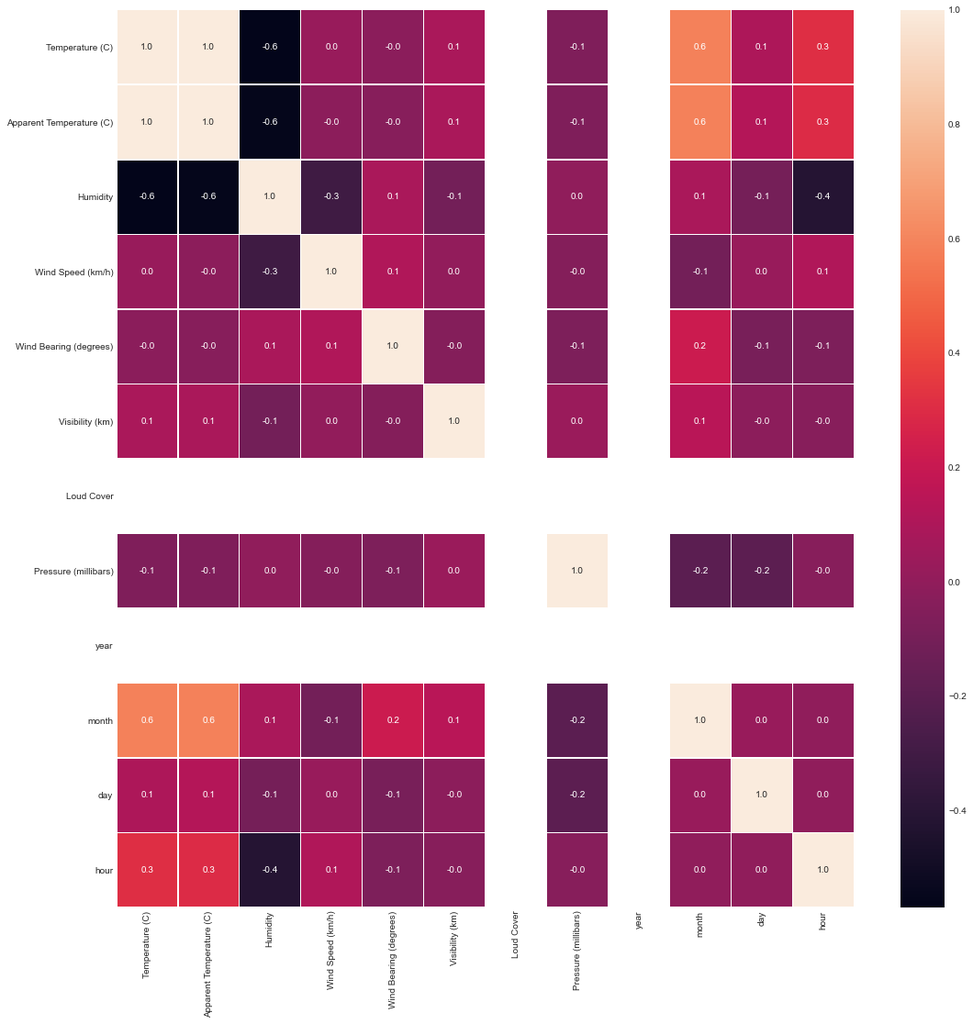

```python
f,ax = plt.subplots(figsize=(18, 18))
sns.heatmap(data.corr(), annot=True, linewidths=.5, fmt= '.1f',ax=ax)
plt.show()
```

**Quantitative variables. Missing values**

```python
data[quantitative].describe()
```

|  | Temperature (C) | Apparent Temperature (C) | Humidity | Wind Speed (km/h) | Wind Bearing (degrees) | Visibility (km) | Loud Cover | Pressure (millibars) |
| --- | --- | --- | --- | --- | --- | --- | --- | --- |
| count | 1464.000000 | 1464.000000 | 1464.000000 | 1464.000000 | 1464.000000 | 1464.000000 | 1464.0 | 1464.000000 |
| mean | 16.116374 | 15.874954 | 0.745587 | 10.244098 | 212.586066 | 11.088490 | 0.0 | 975.016865 |
| std | 5.870141 | 6.384119 | 0.172190 | 6.268961 | 92.230666 | 3.100225 | 0.0 | 190.915136 |
| min | 0.955556 | -0.866667 | 0.320000 | 0.000000 | 0.000000 | 0.289800 | 0.0 | 0.000000 |
| 25% | 12.222222 | 12.222222 | 0.620000 | 5.409600 | 149.000000 | 9.982000 | 0.0 | 1009.170000 |
| 50% | 16.105556 | 16.105556 | 0.780000 | 9.515100 | 223.000000 | 11.125100 | 0.0 | 1012.380000 |
| 75% | 19.956944 | 19.956944 | 0.900000 | 13.882225 | 291.000000 | 11.753000 | 0.0 | 1015.500000 |
| max | 32.638889 | 35.494444 | 1.000000 | 36.386000 | 359.000000 | 16.100000 | 0.0 | 1021.010000 |

```
array([[<AxesSubplot:title={'center':'Temperature (C)'}>,
        <AxesSubplot:title={'center':'Apparent Temperature (C)'}>,
        <AxesSubplot:title={'center':'Humidity'}>],
       [<AxesSubplot:title={'center':'Wind Speed (km/h)'}>,
        <AxesSubplot:title={'center':'Wind Bearing (degrees)'}>,
        <AxesSubplot:title={'center':'Visibility (km)'}>],
       [<AxesSubplot:title={'center':'Loud Cover'}>,
        <AxesSubplot:title={'center':'Pressure (millibars)'}>,
        <AxesSubplot:>]], dtype=object)
```

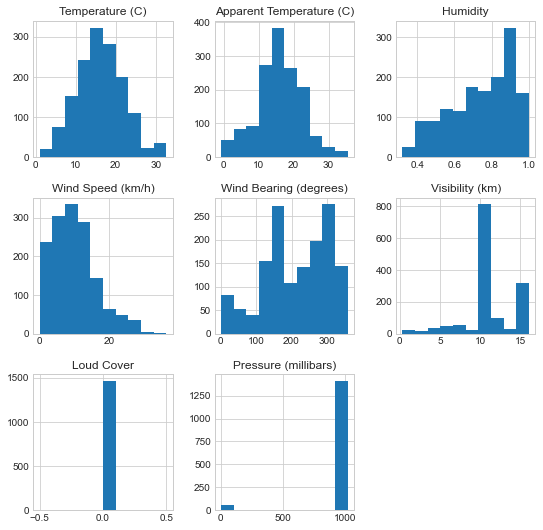

```python
rcParams['figure.figsize'] = 9, 9
data[quantitative].hist()
```

'Loud Cover' takes values zero. We drop it

```python
data=data.drop('Loud Cover',axis=1)
```

"Pressure (millibars)".

Some observations are nil. It seems that they lack values. because the pressure does not take zero as value

Let's fill the zeros with the median:

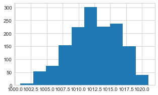

```python
pressure_median = data['Pressure (millibars)'].median()

def pressure(x):
    if x==0:
        return x + pressure_median
    else:
        return x

data["Pressure (millibars)"] = data.apply(lambda row:pressure(row["Pressure (millibars)"]) , axis = 1)

rcParams['figure.figsize'] = 5, 3
data['Pressure (millibars)'].hist()
```

**Categorical variables**

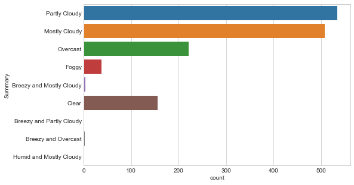

```python
rcParams['figure.figsize'] = 8, 5
sns.countplot(y=data['Summary'])
```

```python
data['Daily Summary'].value_counts(dropna=False)
```

```
Mostly cloudy throughout the day.                                  264
Mostly cloudy until night.                                         144
Partly cloudy starting in the morning.                             144
Partly cloudy throughout the day.                                  120
Partly cloudy until night.                                          96
Partly cloudy until evening.                                        96
Mostly cloudy until evening.                                        96
Foggy in the morning.                                               72
Overcast throughout the day.                                        48
Partly cloudy starting in the afternoon.                            48
Mostly cloudy starting overnight continuing until night.            48
Foggy starting overnight continuing until morning.                  48
Partly cloudy starting in the morning continuing until evening.     24
Mostly cloudy starting overnight.                                   24
Partly cloudy starting overnight continuing until night.            24
Foggy overnight and breezy in the morning.                          24
Partly cloudy until afternoon.                                      24
Partly cloudy until morning.                                        24
Foggy in the evening.                                               24
Mostly cloudy until night and breezy in the afternoon.              24
Partly cloudy starting in the afternoon continuing until night.     24
Partly cloudy starting overnight.                                   24
Name: Daily Summary, dtype: int64
```

```python
data['Summary'].value_counts(dropna=False)
```

```
Partly Cloudy               535
Mostly Cloudy               508
Overcast                    221
Clear                       156
Foggy                        37
Breezy and Mostly Cloudy      3
Breezy and Overcast           2
Humid and Mostly Cloudy       1
Breezy and Partly Cloudy      1
Name: Summary, dtype: int64
```

```python
data['Precip Type'].value_counts(dropna=False)
```

```
rain    1464
Name: Precip Type, dtype: int64
```

```python
data.fillna(method='ffill', inplace=True)
```

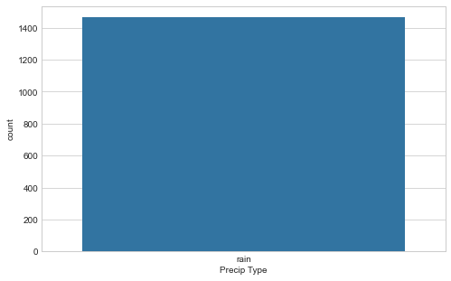

```python
sns.countplot(x=data['Precip Type'])
```

```python
# Calculate total number of cells in dataframe
totalCells = np.product(data.shape)

# Count number of missing values per column
missingCount = data.isnull().sum()

# Calculate total number of missing values
totalMissing = missingCount.sum()

# Calculate percentage of missing values
print("The weather history dataset contains", round(((totalMissing/totalCells) * 100), 2), "%", "missing values.")
```

```
The weather history dataset contains 0.0 % missing values.
```

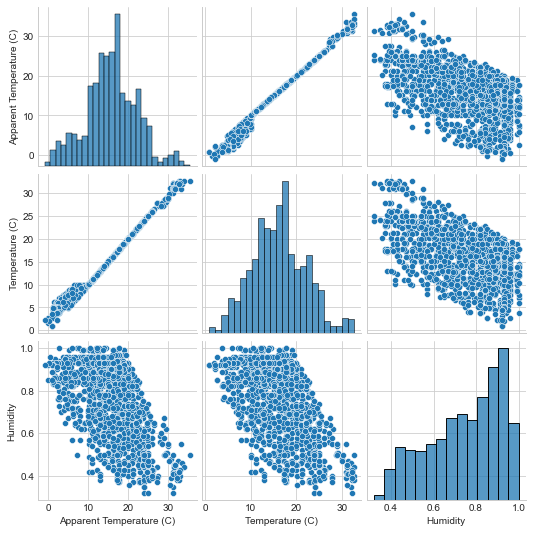

```python
plt.figure(figsize=(18,8)) # this creates a figure 8 inch wide, 4 inch high
sns.pairplot(data[['Apparent Temperature (C)','Temperature (C)', 'Humidity' ]])
plt.show()
```

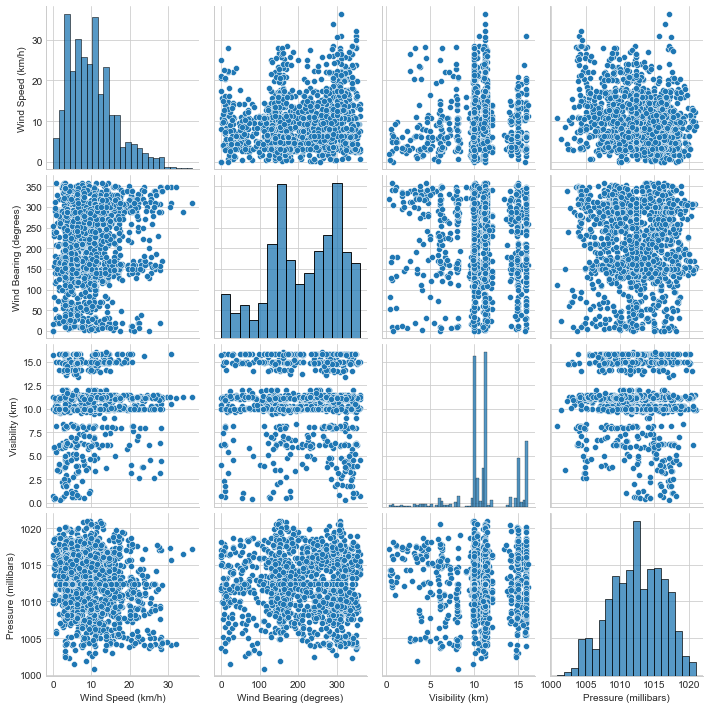

```python
plt.figure(figsize=(18,8)) # this creates a figure 8 inch wide, 4 inch high
sns.pairplot(data[['Wind Speed (km/h)', 'Wind Bearing (degrees)', 'Visibility (km)', 'Pressure (millibars)']])
plt.show()
```

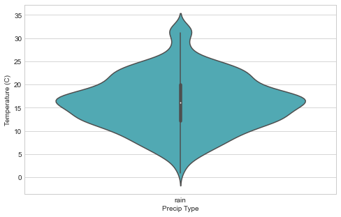

```python
sns.violinplot(x="Precip Type", y="Temperature (C)", data=data, palette="YlGnBu");
```

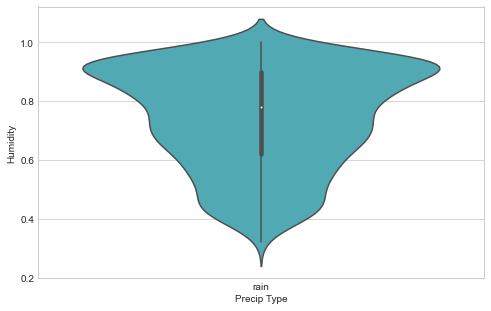

```python
sns.violinplot(x="Precip Type", y="Humidity", data=data, palette="YlGnBu");
```

With these plots we can choose two variables to study the relationship betweem them.

In this study let's focus to explore Temperature as a function of Humidity : how humidity influences in temperature?.

*Linear Regression*

```python
from sklearn import linear_model
from sklearn.model_selection import train_test_split
from sklearn.metrics import mean_squared_error, r2_score

ls = linear_model.LinearRegression()



X = data["Humidity"].values.reshape(-1,1)
y = data["Temperature (C)"].values.reshape(-1,1)

X_train, X_test, y_train, y_test = train_test_split(X,
                                                    y,
                                                    test_size=0.33,
                                                    shuffle=True, random_state=0)
print("Linear Regression")
ls.fit(X_train, y_train)
print("alpha = ",ls.coef_[0])
print("beta = ",ls.intercept_)
print("\n\nCalculating some regression quality metrics")
y_pred = ls.predict(X_test)
print("MSE = ",mean_squared_error(y_test, y_pred))
print("R2 = ",r2_score(y_test, y_pred))
```

```
Linear Regression
alpha =  [-19.55210144]
beta =  [30.56265016]


Calculating some regression quality metrics
MSE =  22.51956589422308
R2 =  0.3164065406855072
```

**Decision Tree Classifier**

first of all i'm going to change the categorical variables to numeric

```python
def change_category_to_number(DailySummaryCat):
    if DailySummaryCat=='Partly cloudy throughout the day.':
        return 1
    elif DailySummaryCat=='Mostly cloudy throughout the day.':
        return 2
    elif DailySummaryCat=='Foggy in the evening.':
        return 3
    elif DailySummaryCat=='Foggy overnight and breezy in the morning.':
        return 4
    elif DailySummaryCat=='Overcast throughout the day.':
        return 5
    elif DailySummaryCat=='Partly cloudy until night.':
        return 6
    elif DailySummaryCat=='Motly cloudy until night.':
        return 7
    elif DailySummaryCat=='Foggy starting overnight continuing until morning.':
        return 8
    elif DailySummaryCat=='Foggy in the morning.':
        return 9
    elif DailySummaryCat=='Partly cloudy until evening.':
        return 10
    elif DailySummaryCat=='Partly cloudy starting in the morning.':
        return 11
    elif DailySummaryCat=='Mostly cloudy starting overnight continuing until night.':
        return 12
    elif DailySummaryCat=='Partly cloudy starting in the afternoon.':
        return 13
    elif DailySummaryCat=='Partly cloudy starting overnight.':
        return 14
    elif DailySummaryCat=='Mostly cloudy starting overnight.':
        return 15
    elif DailySummaryCat=='Mostly cloudy until night and breezy in the afternoon.':
        return 16
    elif DailySummaryCat=='Mostly cloudy until evening.':
        return 17
    elif DailySummaryCat=='Foggy throughout the day.':
        return 18
    elif DailySummaryCat=='Partly cloudy starting in the morning.':
        return 19
    elif DailySummaryCat=='Partly cloudy starting in the morning continuing until evening.':
        return 20
    elif DailySummaryCat=='Foggy until morning.':
        return 21
    elif DailySummaryCat=='Partly cloudy starting in the morning continuing until night.':
        return 22
    elif DailySummaryCat=='Mostly cloudy starting in the morning.':
        return 23
    elif DailySummaryCat=='Foggy starting in the evening.':
        return 24
    elif DailySummaryCat=='Partly cloudy starting in the afternoon continuing until evening.':
        return 25
    elif DailySummaryCat=='Foggy overnight.':
        return 26
    elif DailySummaryCat=='Clear throughout the day.':
        return 27
    elif DailySummaryCat=='Partly cloudy starting overnight continuing until night.':
        return 28
    elif DailySummaryCat=='Partly cloudy overnight.':
        return 29
    elif DailySummaryCat=='Partly cloudy starting overnight continuing until evening.':
        return 30
    elif DailySummaryCat=='Foggy until night.':
        return 31
    elif DailySummaryCat=='Partly cloudy in the morning.':
        return 32
    elif DailySummaryCat=='Foggy starting overnight continuing until afternoon.':
        return 33
    elif DailySummaryCat=='Foggy until afternoon.':
        return 34
    elif DailySummaryCat=='Breezy and mostly cloudy overnight.':
        return 35
    elif DailySummaryCat=='Partly cloudy overnight and breezy starting in the morning continuing until afternoon.':
        return 36
    elif DailySummaryCat=='Breezy in the morning and foggy in the evening.':
        return 37
    elif DailySummaryCat=='Mostly cloudy until evening and breezy in the evening.':
        return 38
    elif DailySummaryCat=='Mostly cloudy starting in the evening.':
        return 39
    elif DailySummaryCat=='Mostly cloudy throughout the day and breezy starting overnight continuing until afternoon.':
        return 40
    elif DailySummaryCat=='Breezy starting in the morning continuing until night.':
        return 41
    elif DailySummaryCat=='Overcast throughout the day and breezy starting overnight continuing until morning.':
        return 42
    elif DailySummaryCat=='Breezy starting overnight continuing until morning and foggy in the evening.':
        return 43
    elif DailySummaryCat=='Light rain until morning.':
        return 44
    elif DailySummaryCat=='Mostly cloudy until night and breezy starting in the afternoon continuing until night.':
        return 45
    elif DailySummaryCat=='Mostly cloudy starting in the morning continuing until afternoon.':
        return 46
    elif DailySummaryCat=='Breezy until afternoon and overcast throughout the day.':
        return 47
    elif DailySummaryCat=='Partly cloudy until evening and breezy in the afternoon.':
        return 48
    elif DailySummaryCat=='Breezy starting overnight continuing until morning and partly cloudy starting overnight continuing until evening.':
        return 49
    elif DailySummaryCat=='Light rain starting overnight.':
        return 50
    elif DailySummaryCat=='Partly cloudy starting overnight continuing until evening and breezy starting in the morning continuing until evening.':
        return 51
    elif DailySummaryCat=='Foggy starting in the morning continuing until evening and breezy in the evening.':
        return 52
    elif DailySummaryCat=='Partly cloudy throughout the day and breezy in the afternoon.':
        return 53
    elif DailySummaryCat=='Mostly cloudy starting overnight continuing until evening and breezy starting overnight continuing until morning.':
        return 54
    elif DailySummaryCat=='Partly cloudy starting overnight continuing until evening and breezy in the morning.':
        return 55
    elif DailySummaryCat=='Overcast throughout the day and breezy overnight.':
        return 56
    elif DailySummaryCat=='Light rain in the morning.':
        return 57
    elif DailySummaryCat=='Rain until morning.':
        return 58
    elif DailySummaryCat=='Breezy in the morning and mostly cloudy starting in the evening.':
        return 59
    elif DailySummaryCat=='Mostly cloudy starting in the morning and breezy overnight.':
        return 60
    elif DailySummaryCat=='Partly cloudy starting overnight and breezy starting in the morning continuing until afternoon.':
        return 61
    elif DailySummaryCat=='Partly cloudy starting in the morning and breezy starting in the afternoon continuing until evening.':
        return 62
    elif DailySummaryCat=='Partly cloudy starting in the morning continuing until evening and breezy in the afternoon.':
        return 63
    elif DailySummaryCat=='Foggy starting overnight continuing until morning and breezy in the afternoon.':
        return 64
```

```python
# assign a numerical value to the categorical field of class, by using the above function
data['DailySummaryCat'] = data['Daily Summary'].apply(change_category_to_number)
```

```python
data.fillna(method='ffill', inplace=True)
```

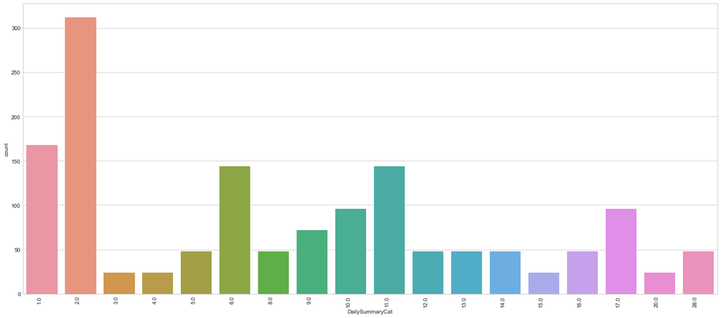

```python
plt.figure(figsize=(18,8)) # this creates a figure 8 inch wide, 4 inch high
ax = sns.countplot(x=data['DailySummaryCat'])
ax.set_xticklabels(ax.get_xticklabels(), rotation=90, ha="right")
plt.tight_layout()
plt.show()
```

```python
def change_category(Summary):
    if Summary=='Partly Cloudy':
        return 1
    elif Summary=='Mostly Cloudy':
        return 2
    elif Summary=='Foggy':
        return 3
    elif Summary=='Clear':
        return 4
    elif Summary=='Overcast':
        return 5
    elif Summary=='Breezy and Overcast':
        return 6
    elif Summary=='Breezy and Partly Cloudy':
        return 7
    elif Summary=='Breezy and Mostly Cloudy':
        return 8
    elif Summary=='Dry and Partly Cloudy':
        return 9
    elif Summary=='Windy and Partly Cloudy':
        return 10
    elif Summary=='Light Rain':
        return 11
    elif Summary=='Breezy':
        return 12
    elif Summary=='Windy and Overcast':
        return 13
    elif Summary=='Humid and Mostly Cloudy':
        return 14
    elif Summary=='Drizzle':
        return 15
    elif Summary=='Windy and Mostly Cloudy':
        return 16
    elif Summary=='Breezy and Foggy':
        return 17
    elif Summary=='Dry':
        return 18
    elif Summary=='Humid and Partly Cloudy':
        return 19
    elif Summary=='Dry and Mostly Cloudy':
        return 20
    elif Summary=='Rain':
        return 21
    elif Summary=='Windy':
        return 22
    elif Summary=='Humid and Overcast':
        return 23
    elif Summary=='Windy and Foggy':
        return 24
    elif Summary=='Dangerously Windy and Partly Cloudy':
        return 25
    elif Summary=='Windy and Dry':
        return 26
    elif Summary=='Breezy and Dry':
        return 27
```

```python
# assign a numerical value to the categorical field of class, by using the above function
data['SummaryCat'] = data['Summary'].apply(change_category)
```

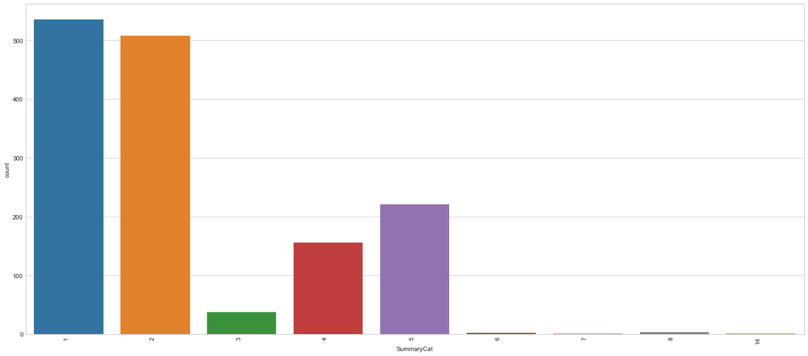

```python
plt.figure(figsize=(18,8)) # this creates a figure 8 inch wide, 4 inch high
ax = sns.countplot(x=data['SummaryCat'])
ax.set_xticklabels(ax.get_xticklabels(), rotation=90, ha="right")
plt.tight_layout()
plt.show()
```

```python
def change_category(PrecipTypeCat):
    if PrecipTypeCat=='rain':
        return 1
    elif PrecipTypeCat=='snow':
        return 2
```

```python
# assign a numerical value to the categorical field of class, by using the above function
data['PrecipTypeCat'] = data['Precip Type'].apply(change_category)
```

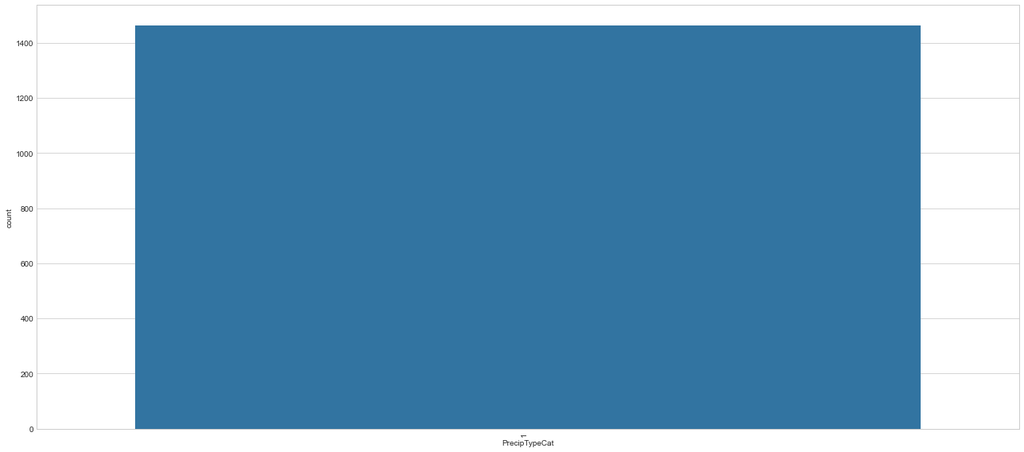

```python
plt.figure(figsize=(18,8)) # this creates a figure 8 inch wide, 4 inch high
ax = sns.countplot(x=data['PrecipTypeCat'])
ax.set_xticklabels(ax.get_xticklabels(), rotation=90, ha="right")
plt.tight_layout()
plt.show()
```

```python
data.drop(['Formatted Date','Summary','Daily Summary','Precip Type','Date'],axis=1,inplace=True)
data.head()
```

|  | Temperature (C) | Apparent Temperature (C) | Humidity | Wind Speed (km/h) | Wind Bearing (degrees) | Visibility (km) | Pressure (millibars) | year | month | day | hour | DailySummaryCat | SummaryCat | PrecipTypeCat |
| --- | --- | --- | --- | --- | --- | --- | --- | --- | --- | --- | --- | --- | --- | --- |
| 0 | 9.472222 | 7.388889 | 0.89 | 14.1197 | 251.0 | 15.8263 | 1015.13 | 2006 | 4 | 1 | 0 | 1.0 | 1 | 1 |
| 1 | 9.355556 | 7.227778 | 0.86 | 14.2646 | 259.0 | 15.8263 | 1015.63 | 2006 | 4 | 1 | 1 | 1.0 | 1 | 1 |
| 2 | 9.377778 | 9.377778 | 0.89 | 3.9284 | 204.0 | 14.9569 | 1015.94 | 2006 | 4 | 1 | 2 | 1.0 | 2 | 1 |
| 3 | 8.288889 | 5.944444 | 0.83 | 14.1036 | 269.0 | 15.8263 | 1016.41 | 2006 | 4 | 1 | 3 | 1.0 | 1 | 1 |
| 4 | 8.755556 | 6.977778 | 0.83 | 11.0446 | 259.0 | 15.8263 | 1016.51 | 2006 | 4 | 1 | 4 | 1.0 | 2 | 1 |

```python
X = data.drop('DailySummaryCat', axis=1)
y = data['DailySummaryCat']
```

```python
X_train, X_test, y_train, y_test = train_test_split(X, y, test_size=0.3, random_state=128)
```

```python
dtClassifer = DecisionTreeClassifier(max_leaf_nodes=15,random_state=0)
```

```python
dtClassifer.fit(X_train, y_train)
```

```
DecisionTreeClassifier(max_leaf_nodes=15, random_state=0)
```

```python
prediction = dtClassifer.predict(X_test)
```

```python
prediction[:100]
```

```
array([ 2., 13.,  2.,  2.,  6.,  6.,  2.,  1.,  2.,  2.,  2.,  6.,  2.,
        2., 17.,  2.,  2., 13.,  2.,  2.,  2.,  2., 17.,  2.,  2.,  2.,
       11.,  6.,  1., 17., 11.,  6.,  2.,  2., 17., 13.,  2.,  2., 17.,
        2.,  2., 13., 13., 17.,  2., 11.,  2., 12.,  2., 11.,  6.,  2.,
       17.,  2.,  2.,  6.,  1.,  3., 13., 17., 11.,  2., 11., 11.,  1.,
       12.,  2., 11., 28., 11.,  1., 13., 13.,  2., 17., 17.,  2.,  2.,
        2.,  1.,  6.,  1., 17.,  1.,  6.,  2.,  2., 17., 17., 17.,  2.,
       11., 13., 17., 17.,  2.,  1., 11.,  2.,  2.])
```

```python
y_test[:100]
```

```
730     14.0
334      9.0
187      2.0
620      9.0
1179     6.0
        ...
1409     2.0
802      1.0
1095    11.0
545      6.0
1406     2.0
Name: DailySummaryCat, Length: 100, dtype: float64
```

```python
accuracy_score(y_true=y_test, y_pred=prediction)
```

```
0.5568181818181818
```

**Logistic Regression**

```python
lrClassifier = LogisticRegression()
```

```python
lrClassifier.fit(X_train,y_train)
```

```
LogisticRegression()
```

```python
prediction = lrClassifier.predict(X_test)
```

```python
prediction[:3000]
```

```
array([ 1.,  2.,  2.,  2., 16.,  2.,  2.,  2.,  2.,  2.,  2.,  2.,  2.,
        2., 17.,  2.,  2.,  2.,  2.,  2.,  2.,  2.,  2.,  2.,  2.,  2.,
        2., 11., 16.,  2.,  2.,  2.,  2.,  2.,  2.,  2.,  2.,  2.,  2.,
        2.,  2.,  2.,  2., 17.,  2.,  2.,  2.,  2.,  2.,  2., 16.,  2.,
       16.,  2.,  2.,  2.,  2.,  2., 17.,  2.,  2.,  2.,  2.,  2.,  2.,
        2.,  2.,  2.,  2., 17.,  2.,  2.,  2.,  2.,  2.,  2.,  2.,  2.,
        2.,  2., 16.,  2.,  2.,  2., 11.,  1.,  2.,  2.,  2.,  1.,  2.,
        2., 17., 11.,  2.,  2.,  2.,  2.,  2.,  2.,  2.,  2., 16.,  2.,
        2.,  2.,  2.,  2., 16.,  2.,  2.,  2.,  2.,  2., 11.,  2.,  2.,
        2.,  2.,  2., 11., 17.,  2., 16.,  2.,  2.,  2.,  2.,  2.,  2.,
        2.,  2.,  2.,  2.,  2.,  2.,  2.,  2.,  2.,  2.,  2.,  2.,  2.,
        2.,  2.,  2.,  2.,  2.,  2.,  2.,  2.,  2., 17.,  2.,  2.,  2.,
        2.,  2.,  2., 11.,  2., 17., 16.,  1.,  2.,  2.,  2.,  2.,  2.,
        2.,  2.,  2.,  2.,  2.,  2.,  2.,  2.,  2.,  2.,  2.,  2.,  2.,
        2.,  2.,  2.,  2.,  2.,  2.,  2.,  2.,  2.,  2.,  2.,  2.,  2.,
        2.,  2.,  2.,  2.,  2.,  2., 16.,  2., 11.,  1.,  2.,  2.,  2.,
       17.,  2.,  2.,  2.,  2.,  2.,  2.,  2.,  2.,  2.,  2.,  2.,  2.,
        2.,  2.,  2.,  2.,  2., 11.,  2.,  2.,  2.,  2.,  2.,  1.,  2.,
        2.,  2.,  2., 16.,  2.,  2.,  2., 16.,  2.,  2.,  2.,  2.,  2.,
        2.,  2.,  2.,  2.,  2.,  2.,  2.,  2.,  2.,  2., 16.,  2.,  2.,
        2., 17.,  2., 16.,  2.,  2.,  2.,  2.,  2.,  2.,  2.,  2.,  2.,
        2., 11.,  2.,  2.,  2.,  2.,  2.,  2.,  2.,  2.,  2.,  2.,  2.,
        2.,  2.,  2.,  2.,  2.,  2.,  2.,  2.,  2.,  2.,  2.,  2.,  2.,
        2.,  2.,  2.,  2.,  1.,  2.,  2.,  2.,  2., 11.,  2.,  2., 16.,
        2.,  2.,  2.,  2.,  2.,  2.,  2.,  2.,  2., 11.,  2.,  2.,  2.,
        2.,  2.,  2.,  2.,  2.,  2.,  2.,  2.,  2., 17.,  2.,  2.,  2.,
        2.,  2.,  2.,  2.,  2.,  2.,  2.,  2.,  2.,  2.,  2., 16.,  2.,
        2.,  2.,  2.,  2.,  2.,  2.,  2.,  2.,  2.,  2.,  2.,  2., 11.,
        2.,  2.,  2.,  2.,  1., 17., 11.,  2.,  2.,  2.,  2.,  2.,  2.,
       11.,  2.,  2.,  2.,  2.,  2.,  2.,  2.,  1., 16.,  2.,  2.,  2.,
        2.,  2.,  2.,  2.,  2.,  2.,  2.,  2.,  2.,  1.,  2.,  2.,  2.,
       11., 11.,  2.,  2.,  2.,  2.,  2., 11.,  2.,  2., 16.,  2.,  2.,
        2.,  2., 17.,  2.,  2.,  2., 17.,  2.,  2., 17., 11.,  2.,  2.,
       11., 11.,  2.,  2.,  2.,  2., 16.,  2.,  1.,  2.,  2.])
```

```python
y_test[:100]
```

```
730     14.0
334      9.0
187      2.0
620      9.0
1179     6.0
        ...
1409     2.0
802      1.0
1095    11.0
545      6.0
1406     2.0
Name: DailySummaryCat, Length: 100, dtype: float64
```

```python
accuracy_score(y_true=y_test, y_pred=prediction)
```

```
0.20909090909090908
```

**Visualization. Weather calendar**

```python
#Drawing a heatmap
def facet_heatmap(data, color, **kws):
    values=data.columns.values[3]
    data = data.pivot(index='day', columns='hour', values=values)
    sns.heatmap(data, cmap='coolwarm', **kws)

#Joining heatmaps of every month in a year
def weather_calendar(year,weather): #Year= Any year in DataFrame. Weather=Any quantitative variable
    datayear = data[data['year']==year][['month', 'day', 'hour', weather]]
    vmin=datayear[weather].min()
    vmax=datayear[weather].max()
    print(vmin, vmax)
    with sns.plotting_context(font_scale=12):
        g = sns.FacetGrid(datayear,col="month", col_wrap=3) #One heatmap per month
        g = g.map_dataframe(facet_heatmap,vmin=vmin, vmax=vmax)
        g.set_axis_labels('Hour', 'Day')
        plt.subplots_adjust(top=0.9)
        g.fig.suptitle('%s Calendar. Year: %s.' %(weather, year), fontsize=18)
```

```
0.9555555555555548 32.638888888888886
```

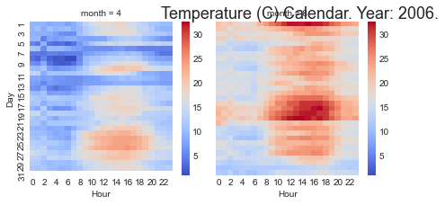

```python
weather_calendar(2006,'Temperature (C)')
```

```
0.32 1.0
```

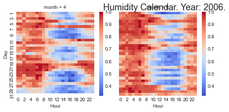

```python
weather_calendar(2006,'Humidity')
```

**Neural Model for Weather Prediction**

```python
data_neur=data
```

```python
data_neur['T'] = data['Temperature (C)']
data_neur['TA'] = data['Apparent Temperature (C)']
data_neur['H'] = data['Humidity']
data_neur['WS'] = data['Wind Speed (km/h)']
data_neur['WB'] = data['Wind Bearing (degrees)']
data_neur['V'] = data['Visibility (km)']
data_neur['P'] = data['Pressure (millibars)']
data_neur['Y'] = data['year']
data_neur['M'] = data['month']
data_neur['D'] = data['day']
data_neur['HR'] = data['hour']
data_neur['SC'] = data['SummaryCat']
data_neur['PT'] = data['PrecipTypeCat']
data.drop(['hour','day','month','year','Pressure (millibars)','Temperature (C)','Apparent Temperature (C)','Humidity','Wind Speed (km/h)','Wind Bearing (degrees)','Visibility (km)','SummaryCat','PrecipTypeCat'],axis=1,inplace=True)
data_neur.head()
```

|  | DailySummaryCat | T | TA | H | WS | WB | V | P | Y | M | D | HR | SC | PT |
| --- | --- | --- | --- | --- | --- | --- | --- | --- | --- | --- | --- | --- | --- | --- |
| 0 | 1.0 | 9.472222 | 7.388889 | 0.89 | 14.1197 | 251.0 | 15.8263 | 1015.13 | 2006 | 4 | 1 | 0 | 1 | 1 |
| 1 | 1.0 | 9.355556 | 7.227778 | 0.86 | 14.2646 | 259.0 | 15.8263 | 1015.63 | 2006 | 4 | 1 | 1 | 1 | 1 |
| 2 | 1.0 | 9.377778 | 9.377778 | 0.89 | 3.9284 | 204.0 | 14.9569 | 1015.94 | 2006 | 4 | 1 | 2 | 2 | 1 |
| 3 | 1.0 | 8.288889 | 5.944444 | 0.83 | 14.1036 | 269.0 | 15.8263 | 1016.41 | 2006 | 4 | 1 | 3 | 1 | 1 |
| 4 | 1.0 | 8.755556 | 6.977778 | 0.83 | 11.0446 | 259.0 | 15.8263 | 1016.51 | 2006 | 4 | 1 | 4 | 2 | 1 |

```python
# X will be a pandas dataframe of all columns except meantempm
X = data_neur[[col for col in data_neur.columns if col != 'DailySummaryCat']]

# y will be a pandas series of the meantempm
y = data_neur['DailySummaryCat']
```

```python
# split data into training set and a temporary set using sklearn.model_selection.traing_test_split
X_train, X_tmp, y_train, y_tmp = train_test_split(X, y, test_size=0.2, random_state=23)
```

```python
# take the remaining 20% of data in X_tmp, y_tmp and split them evenly
X_test, X_val, y_test, y_val = train_test_split(X_tmp, y_tmp, test_size=0.5, random_state=23)

X_train.shape, X_test.shape, X_val.shape
print("Training instances   {}, Training features   {}".format(X_train.shape[0], X_train.shape[1]))
print("Validation instances {}, Validation features {}".format(X_val.shape[0], X_val.shape[1]))
print("Testing instances    {}, Testing features    {}".format(X_test.shape[0], X_test.shape[1]))
```

```
Training instances   1171, Training features   13
Validation instances 147, Validation features 13
Testing instances    146, Testing features    13
```

```python
feature_cols = [tf.feature_column.numeric_column(col) for col in X.columns]
```

```python
regressor = tf.estimator.DNNRegressor(feature_columns=feature_cols,
                                      hidden_units=[50, 50],
                                      model_dir='tf_wx_model')
```

[output not shown]

```python
def wx_input_fn(X, y=None, num_epochs=None, shuffle=True, batch_size=260): # 260 is used as we have approx 570 dataset for training
    return tf.compat.v1.estimator.inputs.pandas_input_fn(x=X,
                                               y=y,
                                               num_epochs=num_epochs,
                                               shuffle=shuffle,
                                               batch_size=batch_size)
```

```python
evaluations = []
STEPS = 260
for i in range(100):
    regressor.train(input_fn=wx_input_fn(X_train, y=y_train), steps=STEPS)
    evaluation = regressor.evaluate(input_fn=wx_input_fn(X_val, y_val,
                                                         num_epochs=1,
                                                         shuffle=False),
                                    steps=1)
    evaluations.append(regressor.evaluate(input_fn=wx_input_fn(X_val,
                                                               y_val,
                                                               num_epochs=1,
                                                               shuffle=False)))
```

[output not shown]

[output cut: 4168 more lines]

[output not shown]

```python
evaluations[0]
```

```
{'average_loss': 36.52645,
 'label/mean': 7.952381,
 'loss': 36.52645,
 'prediction/mean': 8.536579,
 'global_step': 26260}
```

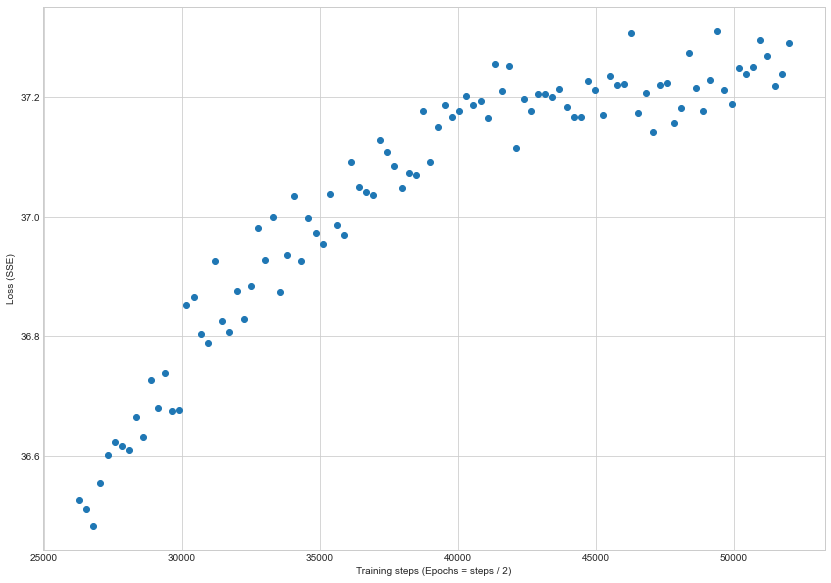

```python
# manually set the parameters of the figure to and appropriate size
plt.rcParams['figure.figsize'] = [14, 10]

loss_values = [ev['loss'] for ev in evaluations]
training_steps = [ev['global_step'] for ev in evaluations]

plt.scatter(x=training_steps, y=loss_values)
plt.xlabel('Training steps (Epochs = steps / 2)')
plt.ylabel('Loss (SSE)')
plt.show()
```